# Introduction to momo

The goal of the *mo*vement *mo*del *momo* is to offer a fast and flexible model and R package that allows estimating habitat preferences and fine-scale movement patterns based on tagging data. To get started, make sure to install the most recent package version from GitHub.

## Installation

The current version of *momo* (v0.0.1) requires R $>= 4.0.0$ and can be downloaded from github as follows.

```r
# install.packages("remotes")
remotes::install_github("tokami/momo")
```

The development version can be installed with:

```r
remotes::install_github("tokami/momo", ref = "dev")
```

## Basic usage

After successful installation, the package can be loaded into the R environment.

A data set containing all required information can quickly be created by the function `sim.momo`. We reduce the number of simulated tags here to speed up the generation of the vignette.

```
#> Tags recaptured outside of spatial domain: 6. Removing them.
```

The main function to estimate movement paramters is `fit.momo`:

```
#> Building the model, that can take a few minutes.
#> Model built (0.14min). Minimizing neg. loglik.
#>   0:     15107.731:  0.00000  0.00000 -4.60517 -4.60517
#>   1:     3903.6683: -0.210143 0.229225 -4.18176 -3.75428
#>   2:     3601.2565: -0.253438 0.142070 -4.17332 -3.73287
#>   3:     3070.6599: -0.230978 0.182554 -4.14248 -3.64977
#>   4:     1837.7957: -0.0964831 0.177516 -4.08991 -3.51149
#>   5:     879.50827: -0.00768805 0.0765048 -4.04276 -3.37117
#>   6:     402.54265: 0.0232660 -0.0175926 -3.99974 -3.20283
#>   7:     51.108215: -0.0708086 0.0756468 -3.95714 -3.05916
#>   8:    -193.27246: 0.0689038 0.0312536 -3.91124 -2.93109
#>   9:    -313.02837: -0.0494347 0.118764 -3.86065 -2.80548
#>  10:    -575.28232: -0.0134744 -0.00449844 -3.77760 -2.67657
#>  11:    -600.70043: -0.0389222 0.0273772 -3.77080 -2.66485
#>  12:    -638.32563: -0.0196999 0.0161858 -3.74488 -2.63876
```

[output cut: 33 more lines]

The package includes a variety of functions that allows to inspect the results:

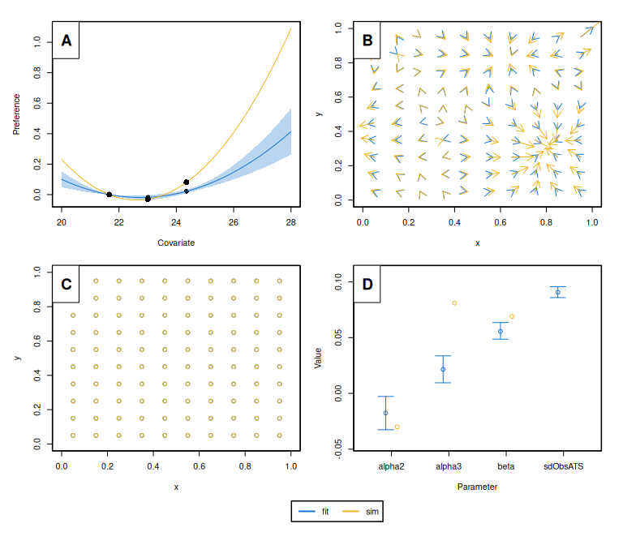

This example illustrates the basic workflow: prepare data (here based on simulation), fit the model, and access results. For real applications, momo supports multiple types of tagging data, customizable environmental covariates, and both estimation and prediction features.

## A more realistic scenario

In a more realistic scenario, the tagging data and environmental fields are not simulated but derived from actual observations, requiring additional data processing before fitting *momo*. The tutorial vignette provides a step-by-step guide to applying *momo* to simulated data that closely mimics real-world observations of skipjack tuna in the Eastern Pacific Ocean. It illustrates the expected data formats and demonstrates how *momo* functions can be used to prepare and structure observational datasets for model fitting.